# Data analysis

## Collecting Data/Data analysis

We have collected our data from the API of health promotion bureau of Sri Lanka. From the meta data file we have extracted the daily PCR tests data and hospitals data island wide.

```r
library(jsonlite)
```

```r
library(ggplot2)
library(lubridate)
#import data
cases<-read.csv("F:/data science competition/confirmed_cases1.csv")
url="https://www.hpb.health.gov.lk/api/get-current-statistical"
rd<-readLines(url, encoding = "UTF-8",warn = F)
meta<- fromJSON(rd, simplifyDataFrame = TRUE)
hos<-meta$data$hospital_data
pcr<-meta$data$daily_pcr_testing_data
pcr$date=as.Date(pcr$date)
```

## Daily PCR Tests in done in Sri Lanka

Following Scatter plot indicates the number of PCR tests done in Sri Lanka daily. It shows that May, August and october months have significantly increased number of PCR tests have done in Sri Lanka. So the number of PCR tests has a huge imapct of new cases found in Sri Lanka nowadays.

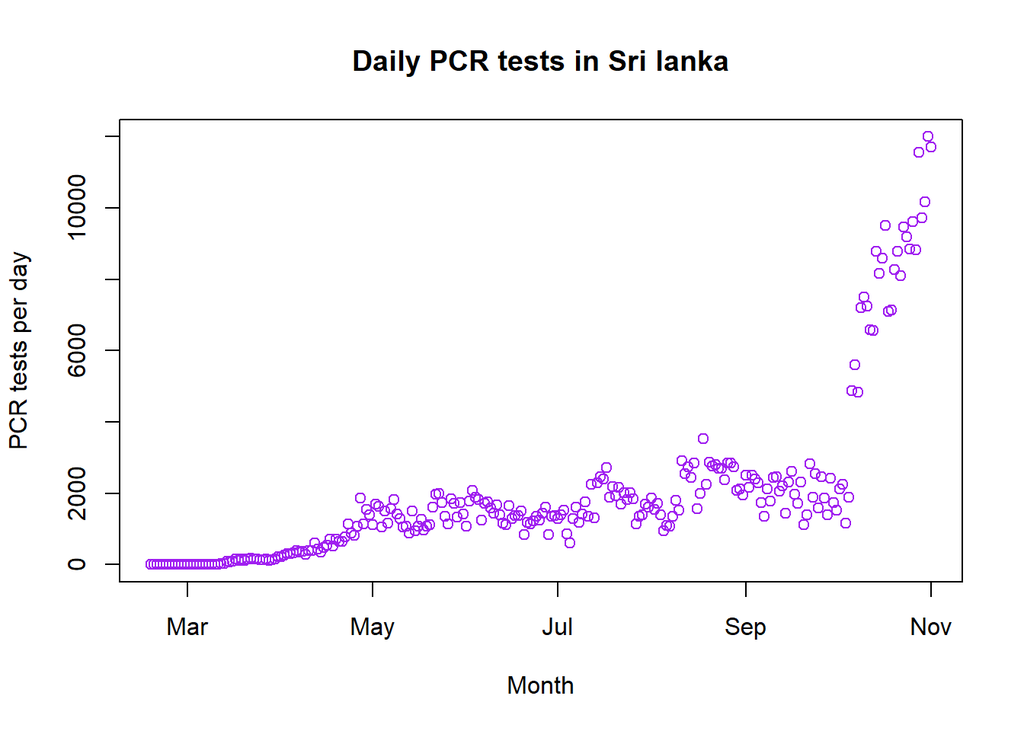

```r
#plot of daily PCR tests
plot(pcr$date,pcr$count, main = "Daily PCR tests in Sri lanka", xlab = "Month",
     ylab = "PCR tests per day",col="purple")
```

## Distribution of patiens in Hospitals islandwide

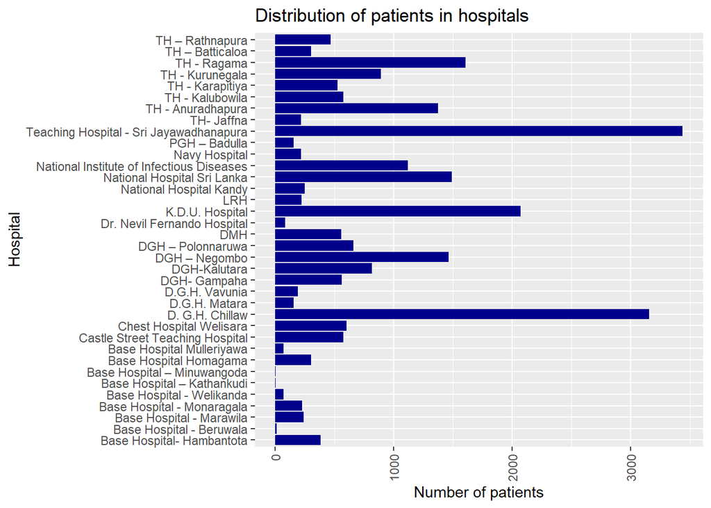

```r
#plot of patients in hospitals
p<-hos$cumulative_local
h<-hos$hospital$name
ggplot(data = hos,aes(p,h))+
  geom_bar(stat="identity",fill="darkblue")+
  theme(axis.text.x=element_text(angle=90,hjust=1,vjust=0.5))+
  labs(title="Distribution of patients in hospitals",
       x ="Number of patients", y = "Hospital")
```

## District and Clusterwise patients in Sri lanka

Following bar graph shows the patients were found in different districts and clusters and the total patients that were found in Sri Lanka.Currently according to those statics Minuwangoda cluster has a huge impact of total number of patients in Sri Lanka. So officials must consider those critical clusters and do their investigations.

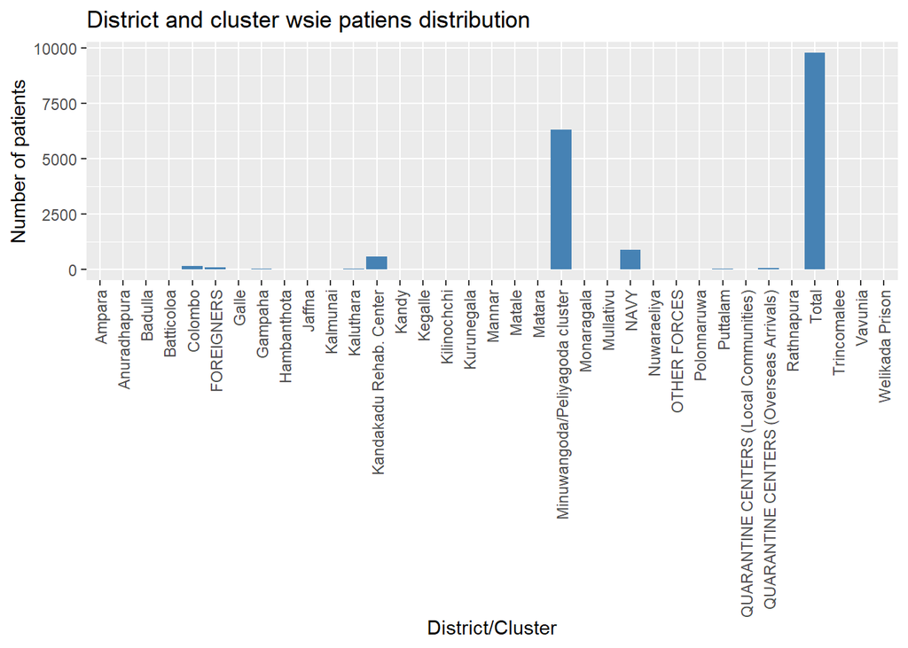

```r
#plot
d<-as.numeric(cases$X[-1])
n<-cases$abc[-1]

ggplot(data = cases[2:36,2:63],aes(n,d))+
  geom_bar(stat="identity",fill="steelblue")+
  theme(axis.text.x=element_text(angle=90,hjust=1,vjust=0.5))+
  labs(title="District and cluster wsie patiens distribution",
       x ="District/Cluster", y = "Number of patients")
```